# Reading In Data

Alan T. Arnholt

Last compiled: July 20, 2023 at 04:18:40 PM

# 1 Data

This section presents a data set that shows how different data types should be read into `R` as well as several functions that are useful for working with different types of `R` objects. Consider the data stored as a CSV file at

https://raw.githubusercontent.com/alanarnholt/Data/master/POPLAR3.CSV

The following description of the data is from `Minitab 15`:

[output not shown]

## 1.1 Base R

The data from Poplar3.CSV is read into the data frame poplar using the `read.csv()` function, and the first five rows of the data frame are shown using the function `head()` with the argument `n = 5` to show the first five rows of the data frame instead of the default `n = 6` rows.

```r
site <- "https://raw.githubusercontent.com/alanarnholt/Data/master/POPLAR3.CSV"
poplar <- read.csv(file = url(site))
head(poplar, n = 5)  # show first five rows
```

```
  site year treatment diameter height weight age
1    1    1         1     2.23   3.76   0.17   3
2    1    1         1     2.12   3.15   0.15   3
3    1    1         1     1.06   1.85   0.02   3
4    1    1         1     2.12   3.64   0.16   3
5    1    1         1     2.99   4.64   0.37   3
```

When dealing with imported data sets, it is always good to examine their contents using functions such as `str()` and `summary()`, which show the structure and provide appropriate summaries, respectively, for different types of objects.

```r
str(poplar)
```

```
'data.frame':   298 obs. of  7 variables:
 $ site     : int  1 1 1 1 1 1 1 1 1 2 ...
 $ year     : int  1 1 1 1 1 1 1 1 1 1 ...
 $ treatment: int  1 1 1 1 1 1 1 1 1 1 ...
 $ diameter : num  2.23 2.12 1.06 2.12 2.99 4.01 2.41 2.75 2.2 4.09 ...
 $ height   : num  3.76 3.15 1.85 3.64 4.64 5.25 4.07 4.72 4.17 5.73 ...
 $ weight   : num  0.17 0.15 0.02 0.16 0.37 0.73 0.22 0.3 0.19 0.78 ...
 $ age      : int  3 3 3 3 3 3 3 3 3 3 ...
```

```r
summary(poplar)
```

```
      site           year        treatment        diameter
 Min.   :1.00   Min.   :1.00   Min.   :1.000   Min.   :-99.000
 1st Qu.:1.00   1st Qu.:1.00   1st Qu.:2.000   1st Qu.:  3.605
 Median :2.00   Median :2.00   Median :2.500   Median :  5.175
 Mean   :1.51   Mean   :1.51   Mean   :2.503   Mean   :  3.862
 3rd Qu.:2.00   3rd Qu.:2.00   3rd Qu.:3.750   3rd Qu.:  6.230
 Max.   :2.00   Max.   :2.00   Max.   :4.000   Max.   :  8.260
     height            weight             age
 Min.   :-99.000   Min.   :-99.000   Min.   :3.000
 1st Qu.:  5.495   1st Qu.:  0.605   1st Qu.:3.000
 Median :  6.910   Median :  1.640   Median :4.000
 Mean   :  5.902   Mean   :  1.099   Mean   :3.507
 3rd Qu.:  8.750   3rd Qu.:  3.435   3rd Qu.:4.000
 Max.   : 10.900   Max.   :  6.930   Max.   :4.000
```

From typing `str(poplar)` at the `R` prompt, one can see that all seven variables are either integer or numeric. From the description, the variables `Site` and `Treatment` are factors. Further investigation into the experiment reveals that `year` and `Age` are factors as well. Recall that factors are an extension of vectors designed for storing categorical information. The results of `summary(poplar)` indicate the minimum values for `Diameter`, `Height`, and `Weight` are all `-99`, which does not make sense unless one is told that a value of `-99` for these variables represents a missing value. Once one understands that the variables `Site`, `Year`, `Treatment`, and `Age` are factors and that the value `-99` has been used to represent missing values for the variables `Diameter`, `Height`, and `Weight`, appropriate arguments to `read.csv()` can be entered. The data is now read into the object `poplarC` using `na.strings = "-99"` to store the `NA` values correctly. The argument `colClasses=` requires a vector that indicates the desired class of each column.

```r
poplarC <- read.csv(file = url(site), na.strings = "-99",
    colClasses = c(rep("factor", 3), rep("numeric", 3), "factor"))
str(poplarC)
```

```
'data.frame':   298 obs. of  7 variables:
 $ site     : Factor w/ 2 levels "1","2": 1 1 1 1 1 1 1 1 1 2 ...
 $ year     : Factor w/ 2 levels "1","2": 1 1 1 1 1 1 1 1 1 1 ...
 $ treatment: Factor w/ 4 levels "1","2","3","4": 1 1 1 1 1 1 1 1 1 1 ...
 $ diameter : num  2.23 2.12 1.06 2.12 2.99 4.01 2.41 2.75 2.2 4.09 ...
 $ height   : num  3.76 3.15 1.85 3.64 4.64 5.25 4.07 4.72 4.17 5.73 ...
 $ weight   : num  0.17 0.15 0.02 0.16 0.37 0.73 0.22 0.3 0.19 0.78 ...
 $ age      : Factor w/ 2 levels "3","4": 1 1 1 1 1 1 1 1 1 1 ...
```

```r
DF <- read.table(file=url(site), header=TRUE)
df <- DF
df[df$var1==999,  "var1"] = NA
df[df$var2==99,   "var2"] = NA
df[df$var3==9999, "var3"] = NA
```

Once a variable has its class changed from `int` to `factor`, labeling the levels of the factor can be accomplished without difficulties. To facilitate analysis of the `poplarC` data, labels for the levels of the variables `Site` and `Treatment` are assigned.

```r
poplarC$site <- factor(poplarC$site, labels = c("Moist", "Dry"))
TreatmentLevels <- c("Control", "Fertilizer", "Irrigation", "FertIrriga")
poplarC$Treatment <- factor(poplarC$treatment, labels = TreatmentLevels)
str(poplarC)
```

```
'data.frame':   298 obs. of  8 variables:
 $ site     : Factor w/ 2 levels "Moist","Dry": 1 1 1 1 1 1 1 1 1 2 ...
 $ year     : Factor w/ 2 levels "1","2": 1 1 1 1 1 1 1 1 1 1 ...
 $ treatment: Factor w/ 4 levels "1","2","3","4": 1 1 1 1 1 1 1 1 1 1 ...
 $ diameter : num  2.23 2.12 1.06 2.12 2.99 4.01 2.41 2.75 2.2 4.09 ...
 $ height   : num  3.76 3.15 1.85 3.64 4.64 5.25 4.07 4.72 4.17 5.73 ...
 $ weight   : num  0.17 0.15 0.02 0.16 0.37 0.73 0.22 0.3 0.19 0.78 ...
 $ age      : Factor w/ 2 levels "3","4": 1 1 1 1 1 1 1 1 1 1 ...
 $ Treatment: Factor w/ 4 levels "Control","Fertilizer",..: 1 1 1 1 1 1 1 1 1 1 ...
```

## 1.2 Using `readr` functions

```r
poplarR <- read_csv(file = url(site))
head(poplarR, n = 5)  # show first five rows
```

```
# A tibble: 5 × 7
   site  year treatment diameter height weight   age
  <dbl> <dbl>     <dbl>    <dbl>  <dbl>  <dbl> <dbl>
1     1     1         1     2.23   3.76   0.17     3
2     1     1         1     2.12   3.15   0.15     3
3     1     1         1     1.06   1.85   0.02     3
4     1     1         1     2.12   3.64   0.16     3
5     1     1         1     2.99   4.64   0.37     3
```

```r
summary(poplarR)
```

```
      site           year        treatment        diameter
 Min.   :1.00   Min.   :1.00   Min.   :1.000   Min.   :-99.000
 1st Qu.:1.00   1st Qu.:1.00   1st Qu.:2.000   1st Qu.:  3.605
 Median :2.00   Median :2.00   Median :2.500   Median :  5.175
 Mean   :1.51   Mean   :1.51   Mean   :2.503   Mean   :  3.862
 3rd Qu.:2.00   3rd Qu.:2.00   3rd Qu.:3.750   3rd Qu.:  6.230
 Max.   :2.00   Max.   :2.00   Max.   :4.000   Max.   :  8.260
     height            weight             age
 Min.   :-99.000   Min.   :-99.000   Min.   :3.000
 1st Qu.:  5.495   1st Qu.:  0.605   1st Qu.:3.000
 Median :  6.910   Median :  1.640   Median :4.000
 Mean   :  5.902   Mean   :  1.099   Mean   :3.507
 3rd Qu.:  8.750   3rd Qu.:  3.435   3rd Qu.:4.000
 Max.   : 10.900   Max.   :  6.930   Max.   :4.000
```

```r
#
poplarR1 <- read_csv(file = url(site), na = "-99")
summary(poplarR1)
```

```
      site           year        treatment        diameter         height
 Min.   :1.00   Min.   :1.00   Min.   :1.000   Min.   :1.030   Min.   : 1.150
 1st Qu.:1.00   1st Qu.:1.00   1st Qu.:2.000   1st Qu.:3.675   1st Qu.: 5.530
 Median :2.00   Median :2.00   Median :2.500   Median :5.200   Median : 6.950
 Mean   :1.51   Mean   :1.51   Mean   :2.503   Mean   :4.909   Mean   : 6.969
 3rd Qu.:2.00   3rd Qu.:2.00   3rd Qu.:3.750   3rd Qu.:6.235   3rd Qu.: 8.785
 Max.   :2.00   Max.   :2.00   Max.   :4.000   Max.   :8.260   Max.   :10.900
                                               NA's   :3       NA's   :3
     weight           age
 Min.   :0.010   Min.   :3.000
 1st Qu.:0.635   1st Qu.:3.000
 Median :1.680   Median :4.000
 Mean   :2.117   Mean   :3.507
 3rd Qu.:3.470   3rd Qu.:4.000
 Max.   :6.930   Max.   :4.000
 NA's   :3
```

```r
str(poplarR1)
```

```
spc_tbl_ [298 × 7] (S3: spec_tbl_df/tbl_df/tbl/data.frame)
 $ site     : num [1:298] 1 1 1 1 1 1 1 1 1 2 ...
 $ year     : num [1:298] 1 1 1 1 1 1 1 1 1 1 ...
 $ treatment: num [1:298] 1 1 1 1 1 1 1 1 1 1 ...
 $ diameter : num [1:298] 2.23 2.12 1.06 2.12 2.99 4.01 2.41 2.75 2.2 4.09 ...
 $ height   : num [1:298] 3.76 3.15 1.85 3.64 4.64 5.25 4.07 4.72 4.17 5.73 ...
 $ weight   : num [1:298] 0.17 0.15 0.02 0.16 0.37 0.73 0.22 0.3 0.19 0.78 ...
 $ age      : num [1:298] 3 3 3 3 3 3 3 3 3 3 ...
 - attr(*, "spec")=
  .. cols(
  ..   site = col_double(),
  ..   year = col_double(),
  ..   treatment = col_double(),
  ..   diameter = col_double(),
  ..   height = col_double(),
  ..   weight = col_double(),
  ..   age = col_double()
  .. )
 - attr(*, "problems")=<externalptr>
```

## 1.3 Using `data.table` function `fread()`

```r
poplarF <- fread(input = site, na.strings = "-99")
str(poplarF)
```

```
Classes 'data.table' and 'data.frame':  298 obs. of  7 variables:
 $ site     : int  1 1 1 1 1 1 1 1 1 2 ...
 $ year     : int  1 1 1 1 1 1 1 1 1 1 ...
 $ treatment: int  1 1 1 1 1 1 1 1 1 1 ...
 $ diameter : num  2.23 2.12 1.06 2.12 2.99 4.01 2.41 2.75 2.2 4.09 ...
 $ height   : num  3.76 3.15 1.85 3.64 4.64 5.25 4.07 4.72 4.17 5.73 ...
 $ weight   : num  0.17 0.15 0.02 0.16 0.37 0.73 0.22 0.3 0.19 0.78 ...
 $ age      : int  3 3 3 3 3 3 3 3 3 3 ...
 - attr(*, ".internal.selfref")=<externalptr>
```

```r
summary(poplarF)
```

```
      site           year        treatment        diameter         height
 Min.   :1.00   Min.   :1.00   Min.   :1.000   Min.   :1.030   Min.   : 1.150
 1st Qu.:1.00   1st Qu.:1.00   1st Qu.:2.000   1st Qu.:3.675   1st Qu.: 5.530
 Median :2.00   Median :2.00   Median :2.500   Median :5.200   Median : 6.950
 Mean   :1.51   Mean   :1.51   Mean   :2.503   Mean   :4.909   Mean   : 6.969
 3rd Qu.:2.00   3rd Qu.:2.00   3rd Qu.:3.750   3rd Qu.:6.235   3rd Qu.: 8.785
 Max.   :2.00   Max.   :2.00   Max.   :4.000   Max.   :8.260   Max.   :10.900
                                               NA's   :3       NA's   :3
     weight           age
 Min.   :0.010   Min.   :3.000
 1st Qu.:0.635   1st Qu.:3.000
 Median :1.680   Median :4.000
 Mean   :2.117   Mean   :3.507
 3rd Qu.:3.470   3rd Qu.:4.000
 Max.   :6.930   Max.   :4.000
 NA's   :3
```

# 2 Graphing Now

Basic scatterplot:

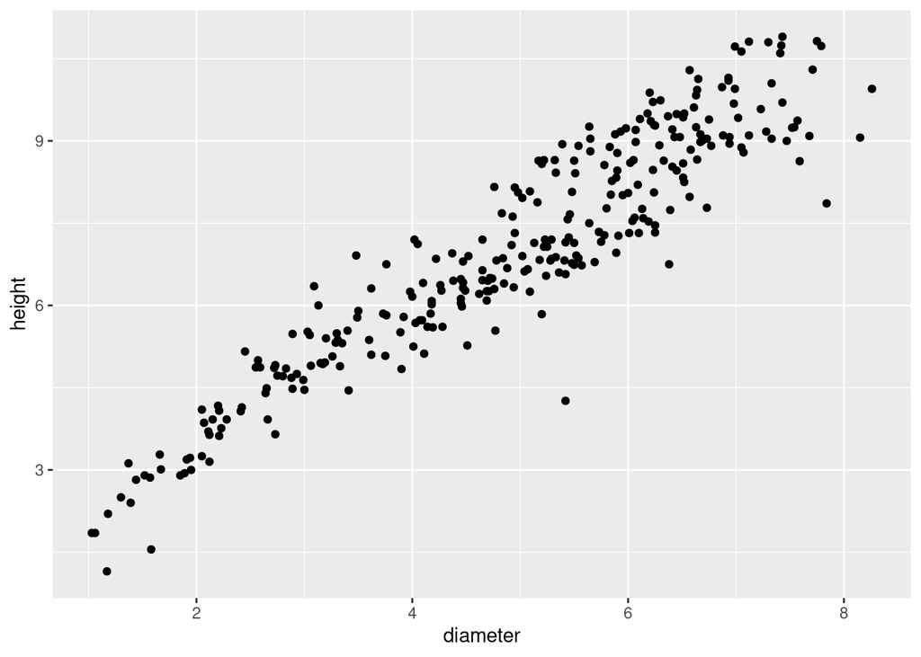

```r
ggplot(data = poplarC, mapping = aes(x = diameter, y = height)) +
  geom_point()
```

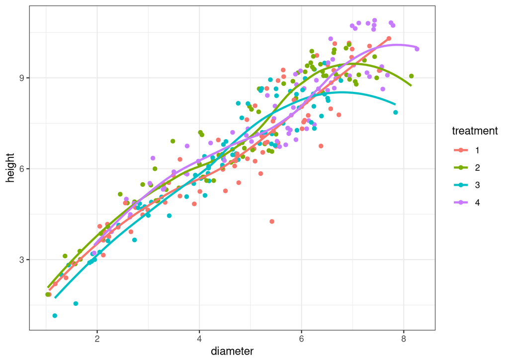

```r
ggplot(data = poplarC, mapping = aes(x = diameter, y = height, color = treatment)) +
  geom_point() +
  theme_bw() +
  geom_smooth(se = FALSE)
```

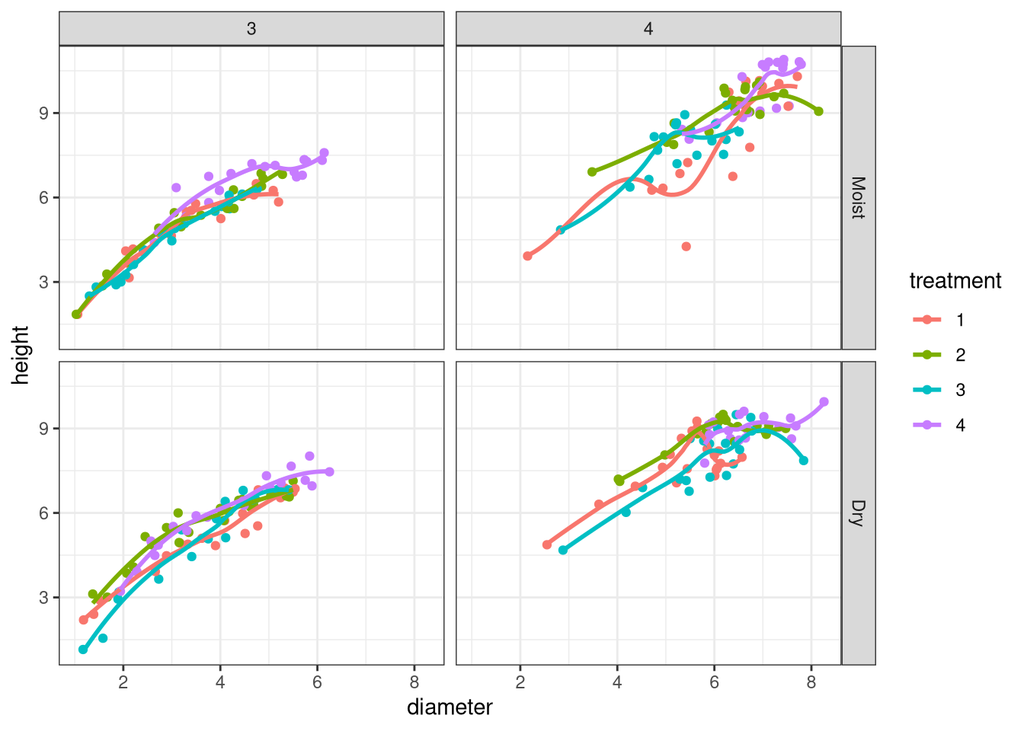

```r
ggplot(data = poplarC, mapping = aes(x = diameter, y = height, color = treatment)) +
  geom_point() +
  theme_bw() +
  geom_smooth(se = FALSE) +
  facet_grid(cols = vars(age), rows = vars(site))
```